# 3-5: Stochastic SIR model

## Overview

*In this practical we start to run a stochastic version of the SIR model.*

## Background

Having created our stochastic version of the SIS model in the previous practical we are now ready to extend this framework to the SIR model.

## Tasks

Using the code from the previous demo d0304_run_SIS and `timestep_stochastic_SIS()` (from Practical 3-4), create two a new demo d0305_run_SIR and a new function, `timestep_stochastic_SIR()` that will simulate the stochastic SIR model.

### R/timestep_stochastic_SIR.R

To produce `timestep_stochastic_SIR()` requires a small change to the update step to move the newly recovered individuals into the recovered class rather than back into the susceptible class. Remember also to include the recovereds in the population size calculation.

To overlay the corresponding plot from the deterministic model you will also need to use `run_simulation()` on the `timestep_deterministic_SIR()` function from Practical 2-4, and then plot using `new.graph = FALSE`.

### demo/d0305_run_SIR.R

This should be relatively straightforward. To produce d0305_run_SIR you need to add a “recovereds” population to the data frame, remembering to specify initial values for this new population.

Your outputs should look something like this:

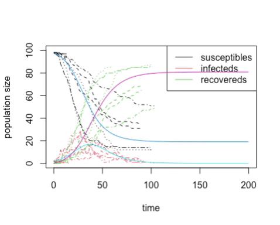

This example was generated from these parameters:

```r
pop.size <- 100
initial.infecteds <- 2
initial.recovereds <- 0
transmission.rate <- 0.2
recovery.rate <- 0.1
```

## Running the code / Report

Run the code for different values of beta, initial conditions, and the population size. Why do the plots of the stochastic simulation end before those of the deterministic simulation? What happens as you increase the population size?

Illustrate some of these effects in your demo.

Now try increasing the transmission rate to increase the value of $R_0$. Given a default value for the recovery rate of 0.1 what would beta need to be to simulate an outbreak with an $R_0$ of 15? What happens when you do this when the time step is 1? You should get an error message saying the time step is too large. You may still get a plot though! This is because R is plotting the previous value of populations held in its memory. This is why it’s important to be aware of your workspace and clear your previous history when you’re working on a new project (don’t use `rm(list=ls())` though!)

> Remember that generating a report starts a new copy of R and so is a much better check of whether the script can run on its own.

Clear what is held in R’s workspace in RStudio. Now rerun with $R_0 = 15$ and confirm that you don’t get an output when the error message shows. Remember that clearing your workspace and trying again is often a very useful trick when you get unexpected results.